# Classification Problem

Mateusz Cedro, Jan Dudzik

2023-02-10

## Goal

The goal of this project was to analyze the characteristics of brain stroke patients dataset and compare performance of various tree-based models, in order to pick the best-performing one.

## Dataset

The dataset contains medical information about 4981 patients, 248 of which suffered from brain stroke. Patients informations include basic personal information like gender and age, work type, residence type or indication if patient was ever married and basic medical information like BMI index, average glucose level, smoking status, heart diseases and hypertension history. The dataset comes from Kaggle and was published with Public Domain License (https://www.kaggle.com/datasets/jillanisofttech/brain-stroke-dataset)

## Models

### Approach

After initial analysis we have transformed average glucose level into logarithmic version due to skewed distribution. The biggest issue we were facing was imbalanced dataset, containing only 4.9789199 % of success values (brain strokes). We have tried using SMOTE algorithm in order to upsample the minority group and compared the results with applying weights to models. In XGBoost model we have used SMOTE as a part of cross validation. We have tried both common values of hyperparameters and best practices knowledge, followed by hyperparameter tuning. At the end we have compared performed three types of models.

### Evaluation Metric

Evaluation of calculated models was performed with Gini Score. In situations, where the Gini Score was similar for two models, we have also considered comparison of Gini Score for train and test data (in order to avoid overfitting) and the ROC Curve, as the treshold in this case should rather be set to maximise Sensitivity.

### Conclusion and Final remarks

Throughout this project, we have overcame the issue of imbalanced dataset with SMOTE algorithm and weights of observations, identified best model for each category and concluded, that for predicting brain stroke of patient, the best-suited model from considered, was the most advanced one, so Extreme Gradient Boosting. It is worth to acknowledge, that AdaBoost method could also be beneficial to consider as a method designed for binary classification.

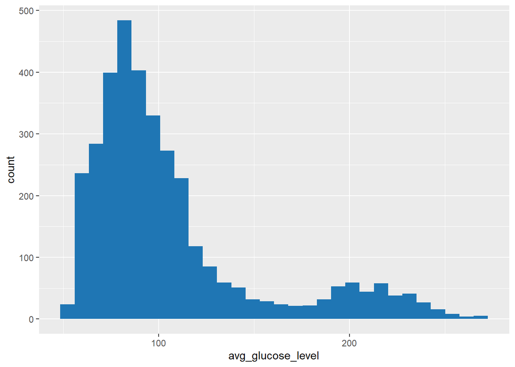

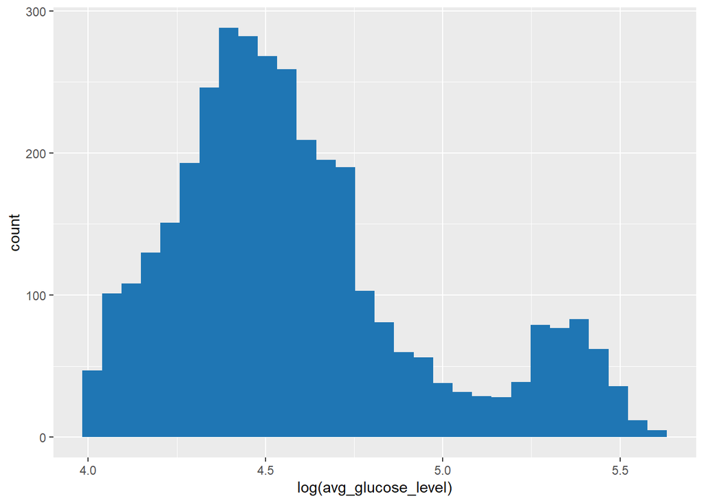

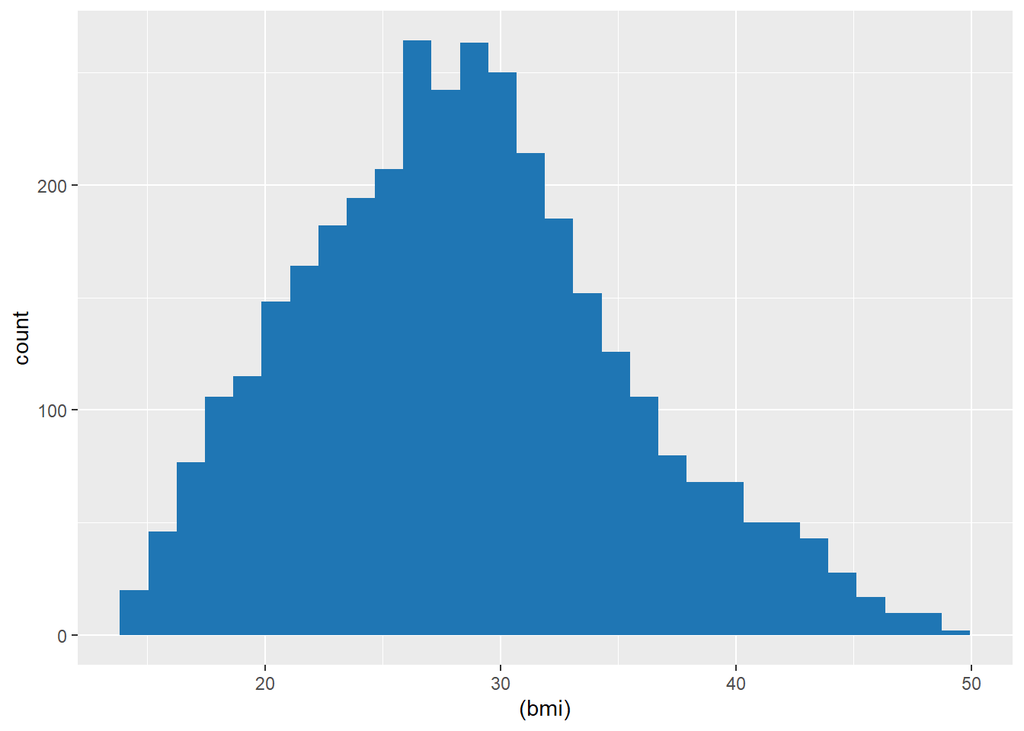

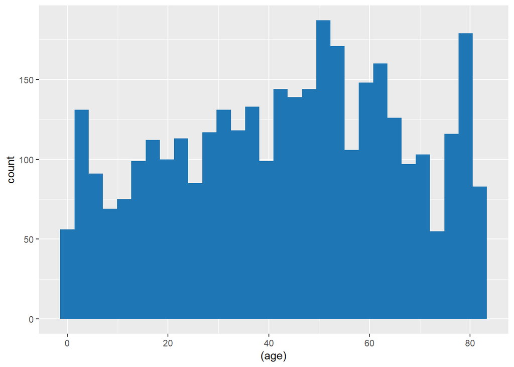

Only the avg Glucose level required logarithmic transformation. Other variables had distribution suitable for modelling.

### Classification Trees

Classification trees models included default hyperparameters model tree1, which became overfitted, tree2 model with more common parameters and assigned weights, tree3 model with beforehand generated, upsampled train dataset obtained with SMOTE algorithm and tree4p model with overgrown and pruned weights-based tree.

Below you can see the comparison of models and complexity of final model tree4p

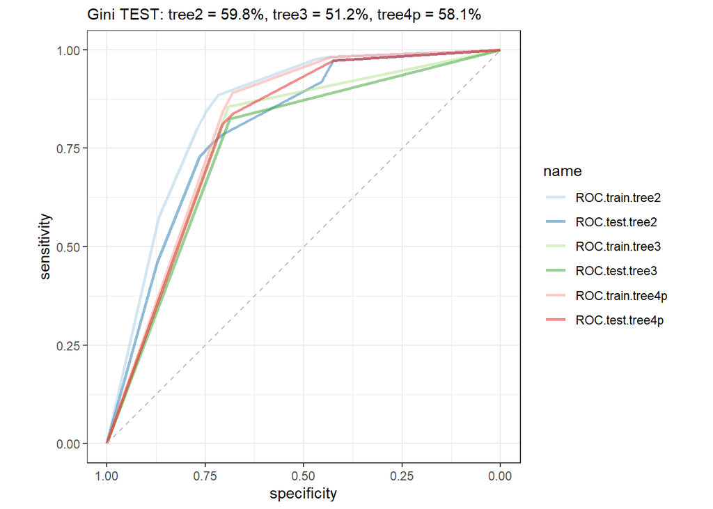

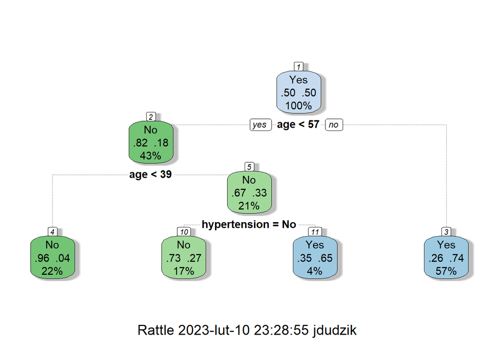

### Random forest

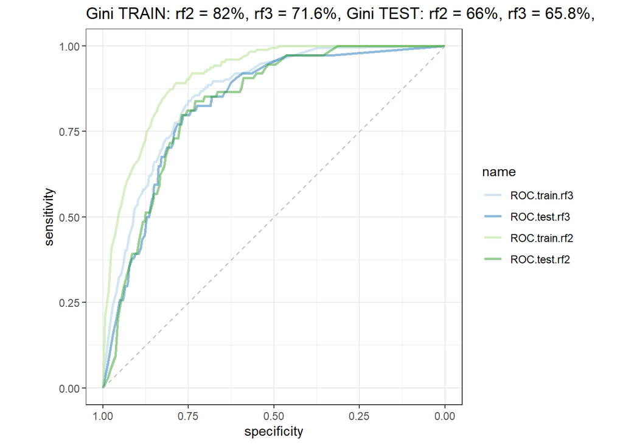

### Extreme Gradient Boosting method

As the last method, we have checked the XGB method. This time we started already with upsampling with SMOTE algorithm inside the cross validation. At first we have set up the hyperparameters according to our best practice knowledge and then we did the hyperparameter tuning. Due to limitations of our machines, we performed the tuning parameter by parameter in following order: 1. Number of iterations, 2. Maximum tree depth, 3. Minimal child weight, 4. Predictors used for splits (colsample_bytree), 5. Size of subsample, 6. Learning rate coefficient. Based on the train sample Gini, XGB7 model, so the last iteration, performed best, although comparing Gini score for Test sample, it turned out, that model 4, so the one with optimal child weight was the optimal one and following optimizations weren’t improving performance. On the ROC Curve chart, we can see that the models performance vary for different treshold levels, although it seems like XGB4 model is performing best. Especially as its the best performing model for higher sensitivity levels, which we are interested in.

```
##             brain_stroke.xgb brain_stroke.xgb2 brain_stroke.xgb3
## Accuracy          0.93975904        0.94243641        0.93775100
## Sensitivity       0.05405405        0.06756757        0.08108108
## Specificity       0.98591549        0.98802817        0.98239437
## Gini              0.64232965        0.65554815        0.60165588
##             brain_stroke.xgb4 brain_stroke.xgb5 brain_stroke.xgb6
## Accuracy            0.8962517         0.8895582         0.9002677
## Sensitivity         0.3108108         0.2837838         0.2837838
## Specificity         0.9267606         0.9211268         0.9323944
## Gini                0.6664065         0.6454987         0.6284355
##             brain_stroke.xgb7
## Accuracy            0.8848728
## Sensitivity         0.3243243
## Specificity         0.9140845
## Gini                0.6544157
```

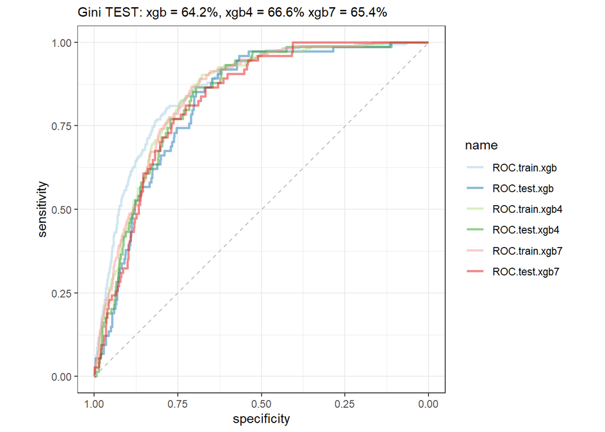

### Final Comparison

For Final comparison, we have picked the best performing models of each type. As could be expected, the best performance was achieved by the most complicated model, which was Extreme Gradient Boosting. In further examples, it could be beneficial to check performance of AdaBoost model and Neural Networks, but this time we were quite limited by computational power.

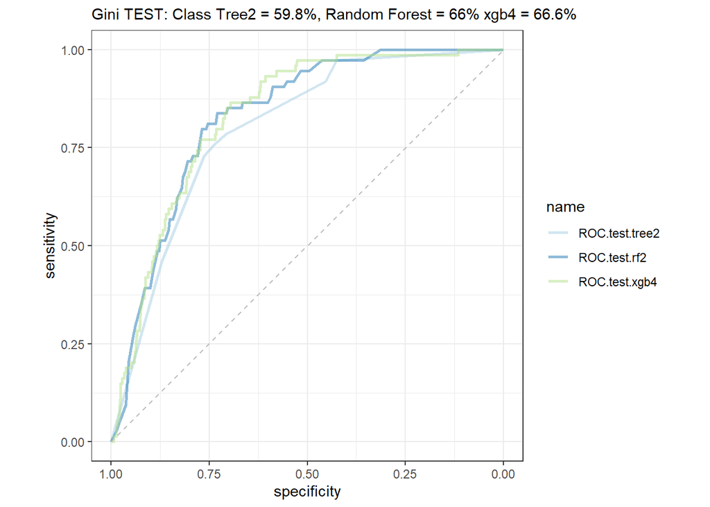